# Презентация по лабораторной работе №15

Амуничников Антон

Российский университет дружбы народов, Москва, Россия

## Докладчик

- Амуничников Антон Игоревич
- 1132227133
- уч. группа: НПИбд-01-22
- Факультет физико-математических и естественных наук
- Российский университет дружбы народов

## Цели

Настроить динамическую маршрутизацию между территориями организации.

## Задачи

1. Настроить динамическую маршрутизацию по протоколу OSPF на маршрутизаторах msk-donskaya-gw-1, msk-q42-gw-1, msk-hostel-gw-1, sch-sochi-gw-1.
2. Настроить связь сети квартала 42 в Москве с сетью филиала в г. Сочи напрямую.
3. В режиме симуляции отследить движение пакета ICMP с ноутбука администратора сети на Донской в Москве (Laptop-PT admin) до компьютера пользователя в филиале в г. Сочи pc-sochi-1.
4. На коммутаторе провайдера отключить временно vlan 6 и в режиме симуляции убедиться в изменении маршрута прохождения пакета ICMP с ноутбука администратора сети на Донской в Москве (Laptop-PT admin) до компьютера пользователя в филиале в г. Сочи pc-sochi-1.
5. На коммутаторе провайдера восстановить vlan 6 и в режиме симуляции убедиться в изменении маршрута прохождения пакета ICMP с ноутбука администратора сети на Донской в Москве (Laptop-PT admin) до компьютера пользователя в филиале в г. Сочи pc-sochi-1.

# Выполнение лабораторной работы

## Настройка OSPF

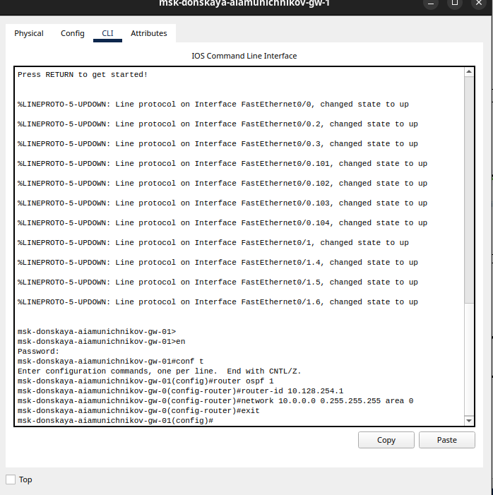

Настройка маршрутизатора msk-donskaya-gw-1

## Настройка OSPF

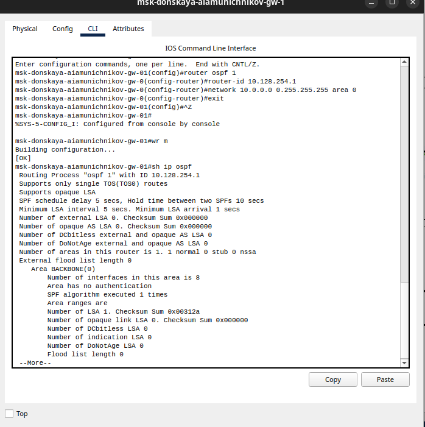

Проверка состояния протокола OSPF на маршрутизаторе msk-donskaya-gw-1

## Настройка OSPF

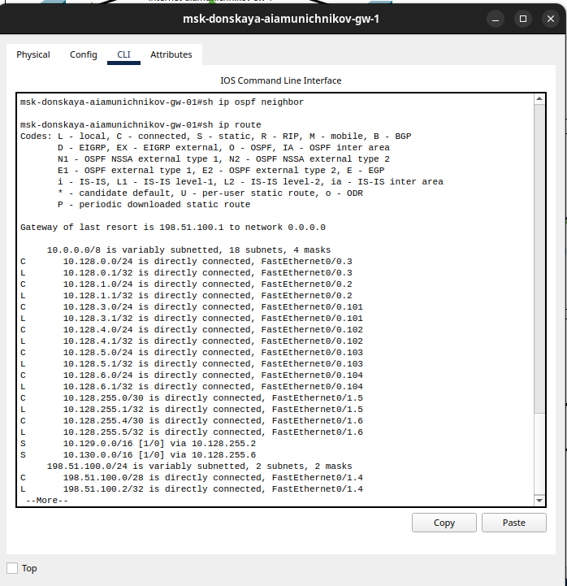

Проверка состояния протокола OSPF на маршрутизаторе msk-donskaya-gw-1

## Настройка OSPF

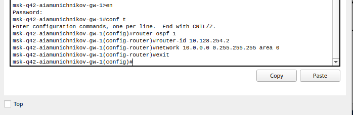

Настройка маршрутизатора msk-q42-gw-1

## Настройка OSPF

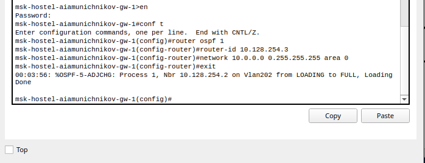

Настройка маршрутизирующего коммутатора msk-hostel-gw-1

## Настройка OSPF

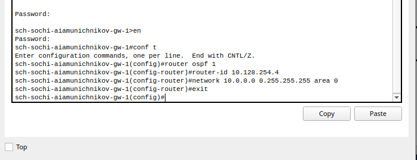

Настройка маршрутизатора sch-sochi-gw-1

## Настройка OSPF

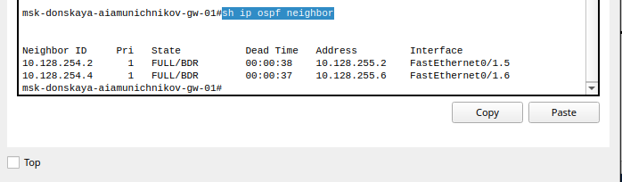

Проверка состояния протокола OSPF на маршрутизаторе msk-donskaya-gw-1

## Настройка OSPF

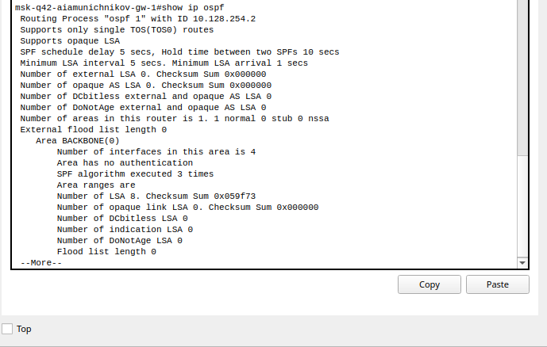

Проверка состояния протокола OSPF на маршрутизаторе msk-q42-gw-1

## Настройка OSPF

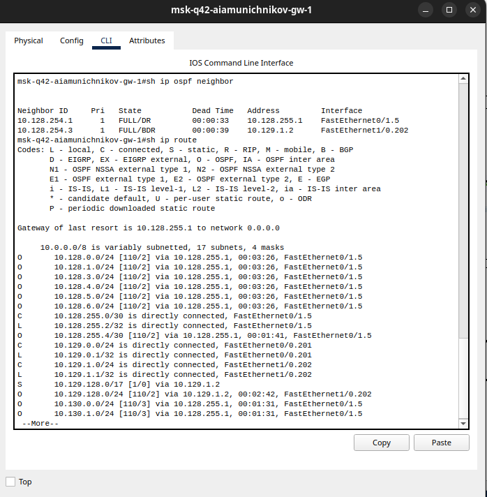

Проверка состояния протокола OSPF на маршрутизаторе msk-q42-gw-1

## Настройка OSPF

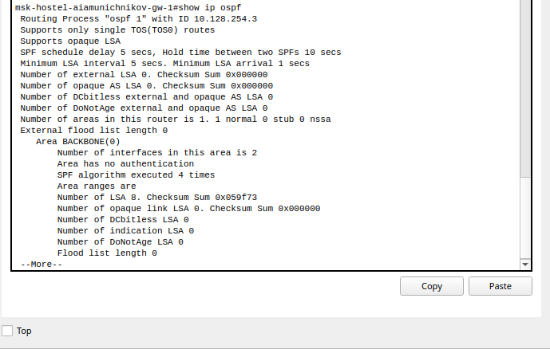

Проверка состояния протокола OSPF на маршрутизирующем коммутаторе msk-hostel-gw-1

## Настройка OSPF

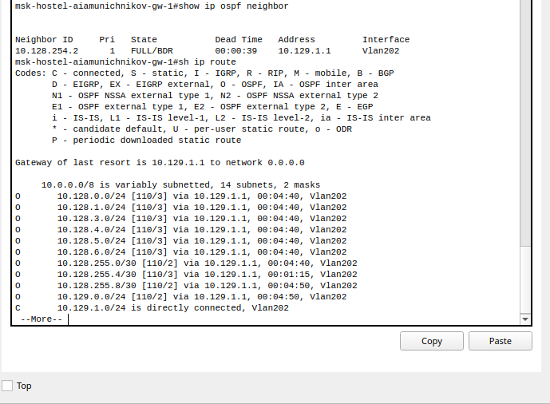

Проверка состояния протокола OSPF на маршрутизирующем коммутаторе msk-hostel-gw-1

## Настройка OSPF

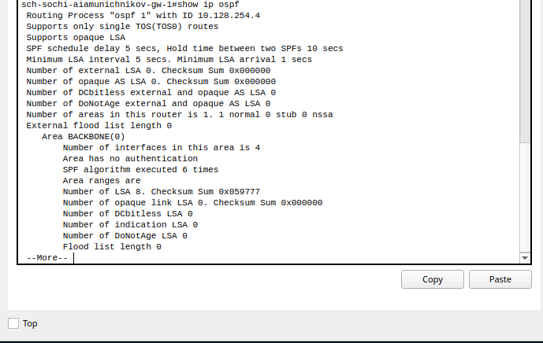

Проверка состояния протокола OSPF на маршрутизаторе sch-sochi-gw-1

## Настройка OSPF

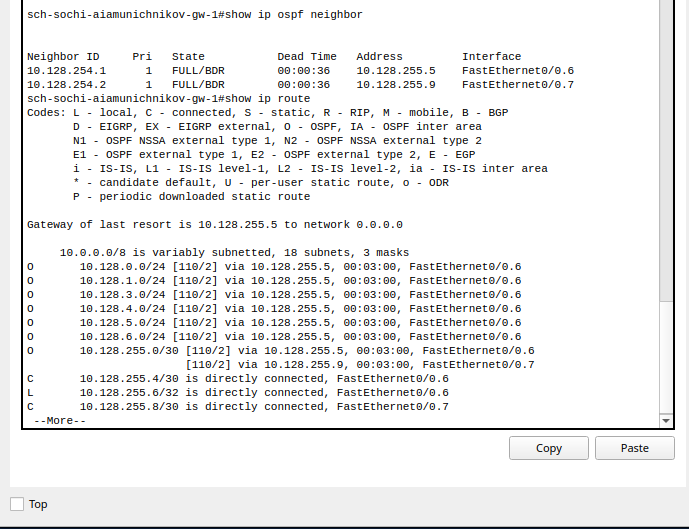

Проверка состояния протокола OSPF на маршрутизаторе sch-sochi-gw-1

## Настройка OSPF

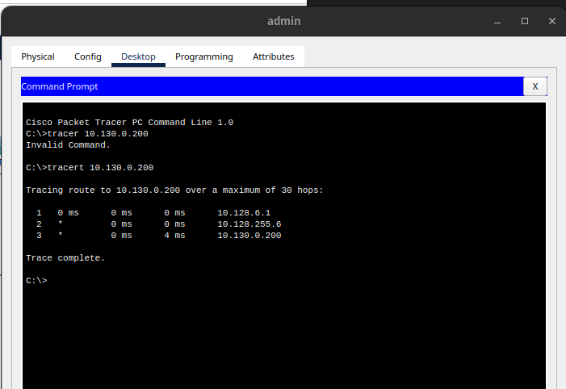

## Настройка линка 42-й квартал–Сочи

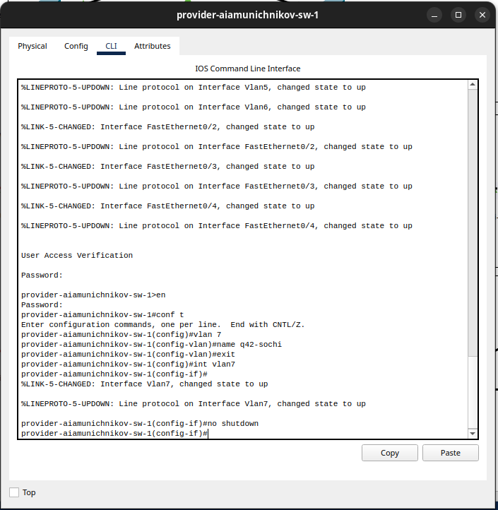

Настройка интерфейсов коммутатора provider-sw-1

## Настройка линка 42-й квартал–Сочи

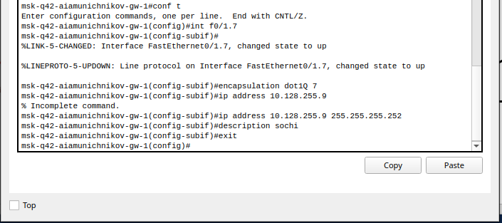

Настройка маршрутизатора msk-q42-gw-1

## Настройка линка 42-й квартал–Сочи

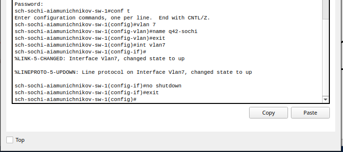

Настройка коммутатора sch-sochi-sw-1

## Настройка линка 42-й квартал–Сочи

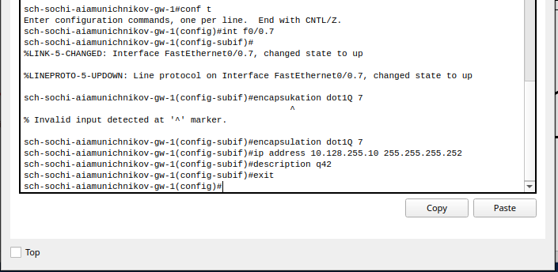

Настройка маршрутизатора sch-sochi-gw-1

## Проверка настроек

[figure not shown]

Движение пакета ICMP при пересылке с администратора на ПК в Сочи в режиме симуляции

## Проверка настроек

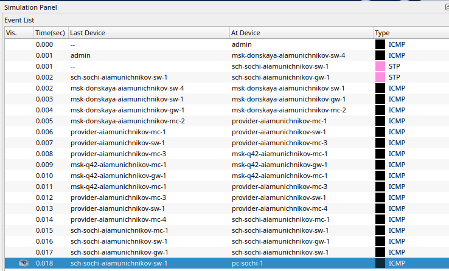

Движение пакета ICMP при пересылке с администратора на ПК в Сочи в режиме симуляции после отключения vlan 6

## Проверка настроек

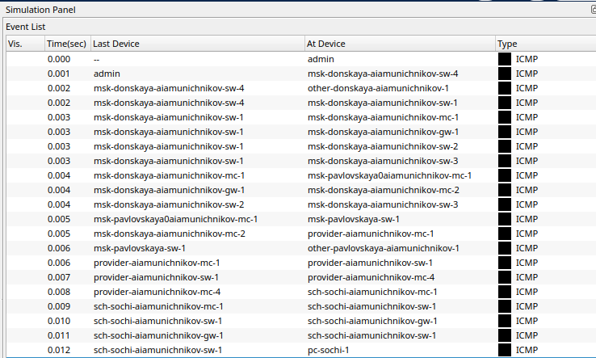

Движение пакета ICMP при пересылке с администратора на ПК в Сочи в режиме симуляции после подключения vlan 6

# Выводы

В результате выполнения лабораторной были приобретены практические навыки по настройке динамической маршрутизации между территориями организации.